## Tarea 4

Programa Experto en Inteligencia Artificial con Python  
ML2000 - Métodos No Supervisados  
Estudiante: Natalia Bonilla Villalobos.

# Menú

- Ejercicio 1
- Ejercicio 2

```python
# !pip install scikit-learn-extra
```

```python
!pip install prince
!pip install -U scikit-learn
!pip install umap-learn
```

```python
# !pip install 'numpy<2'
```

```python
import numpy as np
import pandas as pd
from math import pi
from prince import PCA
from umap.umap_ import UMAP
from sklearn.manifold import TSNE
from sklearn.preprocessing import StandardScaler
from sklearn.preprocessing import MinMaxScaler
from sklearn.cluster import KMeans
import matplotlib.pyplot as plt
import seaborn as sns
# from sklearn_extra.cluster import KMedoids
from sklearn.metrics import silhouette_score
from itertools import cycle
from scipy.spatial.distance import pdist, squareform
from scipy.cluster.hierarchy import ward, single, complete, average
from scipy.cluster.hierarchy import dendrogram, linkage, fcluster
from abc import ABC, abstractmethod
```

# Ejercicio 1

[50 puntos] Para la tabla de dato `Fashion Mnist Data` en el archivo de datos `ropa.csv` realice lo siguiente.

- a) Cargue la tabla de datos `ropa.csv`.

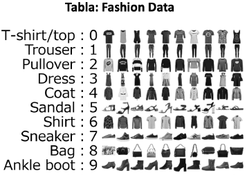

- b) Ejecute los métodos `ACP`, `t-SNE` y `UMAP` con 2 componentes, para `UMAP` pruebe con varias cantidades de vecinos (`n_neighbors`) de manera que el resultado sea lo mejor posible. Luego grafique en 2 dimensiones de manera que se usen diferentes colores para cada unos de los 10 tipos diferentes de ropa. Cuál método da mejores resultados? en el sentido de que separa mejor los 10 tipos de ropa que existen a priori en los datos.

↑ Volver al Menú

## Parte 1

- a) Cargue la tabla de datos `ropa.csv`.
  - 0: T-shirt/top
  - 1: Trouser
  - 2: Pullover
  - 3: Dress
  - 4: Coat
  - 5: Sandal
  - 6: Shirt
  - 7: Sneaker
  - 8: Bag
  - 9: Ankle Boot

```python
df = pd.read_csv('ropa.csv') #, index_col = 0)
df.head()
```

|  | Unnamed: 0 | label | pixel1 | pixel2 | pixel3 | pixel4 | pixel5 | pixel6 | pixel7 | pixel8 | ... | pixel775 | pixel776 | pixel777 | pixel778 | pixel779 | pixel780 | pixel781 | pixel782 | pixel783 | pixel784 |
| --- | --- | --- | --- | --- | --- | --- | --- | --- | --- | --- | --- | --- | --- | --- | --- | --- | --- | --- | --- | --- | --- |
| 0 | 46404 | 8 | 0 | 0 | 0 | 0 | 0 | 0 | 0 | 0 | ... | 0 | 0 | 0 | 0 | 0 | 0 | 0 | 0 | 0 | 0 |
| 1 | 34395 | 8 | 0 | 0 | 0 | 0 | 0 | 0 | 0 | 0 | ... | 0 | 0 | 0 | 0 | 0 | 0 | 0 | 0 | 0 | 0 |
| 2 | 56421 | 0 | 0 | 0 | 0 | 0 | 0 | 0 | 0 | 0 | ... | 187 | 43 | 71 | 70 | 68 | 61 | 49 | 18 | 0 | 0 |
| 3 | 6686 | 8 | 0 | 0 | 0 | 0 | 0 | 0 | 0 | 0 | ... | 140 | 141 | 151 | 140 | 158 | 68 | 0 | 0 | 0 | 0 |
| 4 | 36404 | 8 | 0 | 0 | 0 | 0 | 0 | 0 | 0 | 0 | ... | 0 | 0 | 0 | 0 | 0 | 0 | 0 | 0 | 0 | 0 |

5 rows × 786 columns

```python
pred  = df['label']
df  = df.drop(columns=['Unnamed: 0', 'label'], axis=1)
df.head(3)
```

|  | pixel1 | pixel2 | pixel3 | pixel4 | pixel5 | pixel6 | pixel7 | pixel8 | pixel9 | pixel10 | ... | pixel775 | pixel776 | pixel777 | pixel778 | pixel779 | pixel780 | pixel781 | pixel782 | pixel783 | pixel784 |
| --- | --- | --- | --- | --- | --- | --- | --- | --- | --- | --- | --- | --- | --- | --- | --- | --- | --- | --- | --- | --- | --- |
| 0 | 0 | 0 | 0 | 0 | 0 | 0 | 0 | 0 | 0 | 0 | ... | 0 | 0 | 0 | 0 | 0 | 0 | 0 | 0 | 0 | 0 |
| 1 | 0 | 0 | 0 | 0 | 0 | 0 | 0 | 0 | 0 | 0 | ... | 0 | 0 | 0 | 0 | 0 | 0 | 0 | 0 | 0 | 0 |
| 2 | 0 | 0 | 0 | 0 | 0 | 0 | 0 | 0 | 0 | 23 | ... | 187 | 43 | 71 | 70 | 68 | 61 | 49 | 18 | 0 | 0 |

3 rows × 784 columns

## Parte 2

- b) Ejecute los métodos `ACP`, `t-SNE` y `UMAP` con 2 componentes, para `UMAP` pruebe con varias cantidades de vecinos (`n_neighbors`) de manera que el resultado sea lo mejor posible. Luego grafique en 2 dimensiones de manera que se usen diferentes colores para cada unos de los 10 tipos diferentes de ropa. Cuál método da mejores resultados? en el sentido de que separa mejor los 10 tipos de ropa que existen a priori en los datos.

```python
datos_escalados = StandardScaler().fit_transform(df)
datos_escalados = pd.DataFrame(datos_escalados)
datos_escalados.columns = df.columns
datos_escalados.index = df.index
datos_escalados.head()
```

|  | pixel1 | pixel2 | pixel3 | pixel4 | pixel5 | pixel6 | pixel7 | pixel8 | pixel9 | pixel10 | ... | pixel775 | pixel776 | pixel777 | pixel778 | pixel779 | pixel780 | pixel781 | pixel782 | pixel783 | pixel784 |
| --- | --- | --- | --- | --- | --- | --- | --- | --- | --- | --- | --- | --- | --- | --- | --- | --- | --- | --- | --- | --- | --- |
| 0 | 0.0 | 0.0 | -0.069739 | -0.066331 | -0.077647 | -0.097455 | -0.108138 | -0.158156 | -0.228335 | -0.367692 | ... | -0.572101 | -0.464175 | -0.404239 | -0.420419 | -0.477940 | -0.434200 | -0.306545 | -0.161909 | -0.097909 | 0.0 |
| 1 | 0.0 | 0.0 | -0.069739 | -0.066331 | -0.077647 | -0.097455 | -0.108138 | -0.158156 | -0.228335 | -0.367692 | ... | -0.572101 | -0.464175 | -0.404239 | -0.420419 | -0.477940 | -0.434200 | -0.306545 | -0.161909 | -0.097909 | 0.0 |
| 2 | 0.0 | 0.0 | -0.069739 | -0.066331 | -0.077647 | -0.097455 | -0.108138 | -0.158156 | -0.228335 | 0.212105 | ... | 2.836192 | 0.447760 | 1.357530 | 1.080770 | 0.764317 | 0.867462 | 1.416805 | 0.884918 | -0.097909 | 0.0 |
| 3 | 0.0 | 0.0 | -0.069739 | -0.066331 | -0.077647 | -0.097455 | -0.108138 | -0.158156 | -0.228335 | -0.367692 | ... | 1.979562 | 2.526123 | 3.342622 | 2.581959 | 2.408480 | 1.016833 | -0.306545 | -0.161909 | -0.097909 | 0.0 |
| 4 | 0.0 | 0.0 | -0.069739 | -0.066331 | -0.077647 | -0.097455 | -0.108138 | -0.158156 | -0.228335 | -0.367692 | ... | -0.572101 | -0.464175 | -0.404239 | -0.420419 | -0.477940 | -0.434200 | -0.306545 | -0.161909 | -0.097909 | 0.0 |

5 rows × 784 columns

**Función impresión del Plano Principal**

```python
def print_reduccion_dim(individuos, pred):
  x = individuos.iloc[:, 0]
  y = individuos.iloc[:, 1]
  fig, ax = plt.subplots(figsize = (10, 6))

  for cat in pred.unique():
    no_print = ax.scatter(x[pred == cat], y[pred == cat], label = cat, alpha=0.5)

  no_print = ax.axhline(y = 0, color = 'dimgrey', linestyle = '--')
  no_print = ax.axvline(x = 0, color = 'dimgrey', linestyle = '--')
  no_print = ax.set_xlabel('Componente 1')
  no_print = ax.set_ylabel('Componente 2')
  no_print = ax.legend(title='Fashion', title_fontsize=13, fontsize=11, loc='upper right', bbox_to_anchor=(1.3, 1))

  no_print = plt.legend()
  plt.show()
```

### **PCA**

```python
pca = PCA(n_components=2)
pca_scaled = pca.fit(datos_escalados)
```

```python
individuos_pca = pca.row_coordinates(datos_escalados)
individuos_pca.head(5)
```

| component | 0 | 1 |
| --- | --- | --- |
| 0 | 13.821532 | 17.016699 |
| 1 | -10.859221 | 13.711510 |
| 2 | 20.073081 | 5.252293 |
| 3 | 1.743839 | -3.952290 |
| 4 | 0.820814 | 21.269512 |

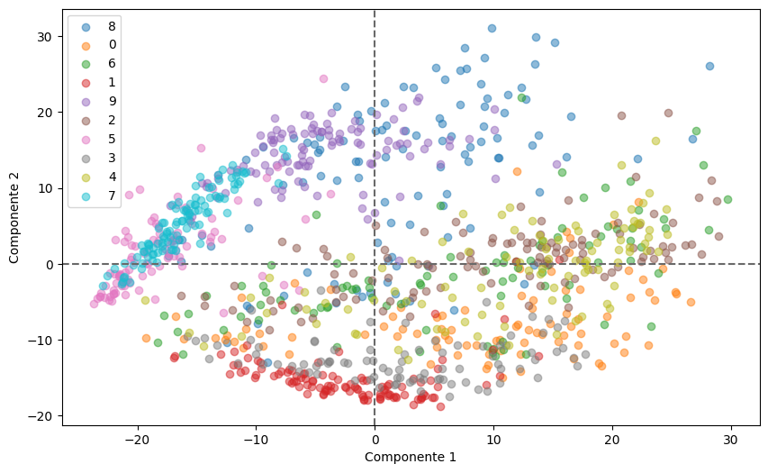

```
0: T-shirt/top, 1: Trouser, 2: Pullover, 3: Dress, 4: Coat, 5: Sandal, 6: Shirt, 7: Sneaker, 8: Bag, 9: Ankle Boot
```

```python
print_reduccion_dim(individuos_pca, pred)
print("0: T-shirt/top, 1: Trouser, 2: Pullover, 3: Dress, 4: Coat, 5: Sandal, 6: Shirt, 7: Sneaker, 8: Bag, 9: Ankle Boot")
```

### **T-SNE**

```python
tsne = TSNE(n_components=2, perplexity=25, learning_rate='auto', init='random')
individuos_tsne = tsne.fit_transform(datos_escalados)
individuos_tsne = pd.DataFrame(individuos_tsne, index = datos_escalados.index)
individuos_tsne.head(5)
```

|  | 0 | 1 |
| --- | --- | --- |
| 0 | -7.743351 | 17.104883 |
| 1 | -16.385534 | 14.847977 |
| 2 | 13.020961 | 25.754004 |
| 3 | 9.941325 | -9.613121 |
| 4 | -15.413054 | 16.907457 |

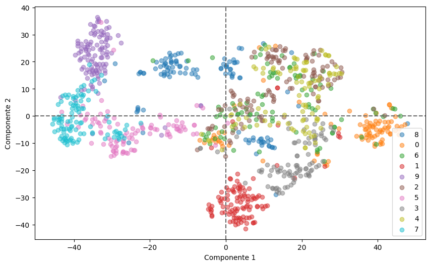

```
0: T-shirt/top, 1: Trouser, 2: Pullover, 3: Dress, 4: Coat, 5: Sandal, 6: Shirt, 7: Sneaker, 8: Bag, 9: Ankle Boot
```

```python
print_reduccion_dim(individuos_tsne, pred)
print("0: T-shirt/top, 1: Trouser, 2: Pullover, 3: Dress, 4: Coat, 5: Sandal, 6: Shirt, 7: Sneaker, 8: Bag, 9: Ankle Boot")
```

### **UMAP**

```python
umap = UMAP(n_components=2, n_neighbors=5)
individuos_umap = umap.fit_transform(datos_escalados)
individuos_umap = pd.DataFrame(individuos_umap, index = datos_escalados.index)
individuos_umap.head(5)
```

|  | 0 | 1 |
| --- | --- | --- |
| 0 | 2.686224 | -2.602225 |
| 1 | 2.414012 | -3.663429 |
| 2 | 5.778934 | -0.797917 |
| 3 | 3.625713 | 0.806504 |
| 4 | 2.348567 | -3.461853 |

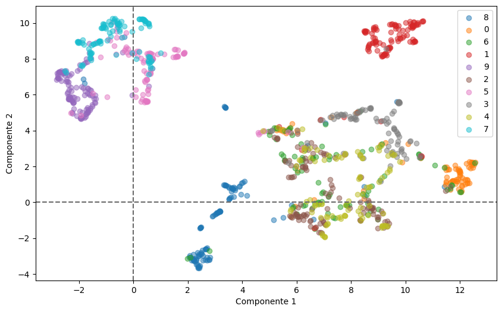

```
0: T-shirt/top, 1: Trouser, 2: Pullover, 3: Dress, 4: Coat, 5: Sandal, 6: Shirt, 7: Sneaker, 8: Bag, 9: Ankle Boot
```

```python
print_reduccion_dim(individuos_umap, pred)
print("0: T-shirt/top, 1: Trouser, 2: Pullover, 3: Dress, 4: Coat, 5: Sandal, 6: Shirt, 7: Sneaker, 8: Bag, 9: Ankle Boot")
```

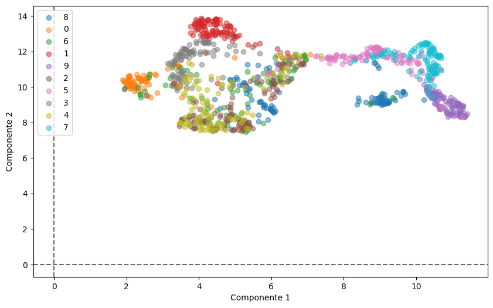

```
0: T-shirt/top, 1: Trouser, 2: Pullover, 3: Dress, 4: Coat, 5: Sandal, 6: Shirt, 7: Sneaker, 8: Bag, 9: Ankle Boot
```

```python
umap = UMAP(n_components=2, n_neighbors=70)
individuos_umap = umap.fit_transform(datos_escalados)
individuos_umap = pd.DataFrame(individuos_umap, index = datos_escalados.index)
print_reduccion_dim(individuos_umap, pred)
print("0: T-shirt/top, 1: Trouser, 2: Pullover, 3: Dress, 4: Coat, 5: Sandal, 6: Shirt, 7: Sneaker, 8: Bag, 9: Ankle Boot")
```

# Ejercicio 2

[50 puntos] Utilice el conjunto de datos `StressLevel.csv`. Este conjunto contiene información obtenida de una encuesta a estudiantes universitarios, con el objetivo de identificar factores asociados al estrés académico. La tabla cuenta con N filas (estudiantes) y 20 variables descritas a continuación:

- **Factores psicológicos:**
  - `anxiety_level`: Nivel de ansiedad reportado. Escala numerica discreta (mayores valores = más ansiedad).
  - `self_esteem`: Nivel de autoestima. Escala numerica discreta (valores altos = mayor autoestima).
  - `mental_health_history`: Antecedentes de salud mental (0 = No, 1 = Sí). Variable categórica binaria.
  - `depression`: Puntaje de síntomas depresivos. Numerica discreta (valores altos = mayor depresión).
- **Factores fisiológicos:**
  - `headache`: Frecuencia de dolores de cabeza. Categórica ordinal (0 = nunca, 5 = muy frecuente).
  - `blood_pressure`: Nivel de presión arterial. Categórica ordinal (1 = baja, 2 = normal, 3 = alta).
  - `sleep_quality`: Calidad del sueño. Categórica ordinal (0 = muy mala, 5 = muy buena).
  - `breathing_problem`: Presencia de problemas respiratorios. Categórica ordinal (0 = nunca, 5 = muy frecuente).
- **Factores ambientales:**
  - `noise_level`: Nivel de ruido en el entorno. Categórica ordinal (0 = bajo, 5 = muy alto).
  - `living_conditions`: Condiciones de vida del estudiante. Categórica ordinal (0 = muy malas, 5 = muy buenas).
  - `safety`: Percepción de seguridad en el entorno. Categórica ordinal (0 = nada seguro, 5 = muy seguro).
  - `basic_needs`: Grado de satisfacción de necesidades básicas (alimentación, vivienda). Categórica ordinal (0 = insatisfechas, 5 = totalmente satisfechas).
- **Factores académicos:**
  - `academic_performance`: Confianza en el rendimiento académico. Categórica ordinal (0 = muy baja, 5 = muy alta).
  - `study load`: Percepción de la carga académica. Categórica ordinal (0 = muy ligera, 5 = muy pesada).
  - `teacher_student_relationship`: Calidad de la relación con los profesores. Categórica ordinal (0 = muy mala, 5 = muy buena).
  - `future_career_concerns`: Preocupación por la carrera futura. Categórica ordinal (0 = nada preocupado, 5 = muy preocupado).
- **Factores sociales:**
  - `social_support`: Nivel de apoyo social percibido. Categórica ordinal (0 = muy bajo, 5 = muy alto).
  - `peer_pressure`: Presión ejercida por los pares. Categórica ordinal (0 = nula, 5 = muy alta).
  - `extracurricular_activities`: Participación en actividades extracurriculares. Categórica ordinal (0 = nula, 5 = muy alta).
  - `bullying`: Presencia de acoso escolar. Categórica ordinal (0 = nunca, 5 = muy frecuente).
- **Variable objetivo:**
  - `stress_type`: Tipo de estrés que experimenta principalmente el estudiante. Variable categórica con tres clases posibles: No Stress = 0, Eustress = 1, Distress = 2.

**Realice lo siguiente:**

- a) Convierta todas las variables a numéricas.
- b) Ejecute los métodos `ACP`, `t-SNE` y `UMAP`, conservando las dos primeras componentes. En el caso de `UMAP` , ajuste el parámetro (`n_neighbors`) para obtener el mejor resultado posible.
- c) Ejecute el método de `KMeans(...)` ccon 3 clústeres (utilice los parámetros que considere más adecuados), tomando como entrada las dos primeras componentes generadas por `ACP`, `t-SNE` y `UMAP`. Grafique los respectivos planos principales utilizando colores según los grupos generados.
- d) Compare e interprete los resultados obtenidos en el punto anterior mediante gráficos de barras y gráficos tipo radar. Cuál de los métodos genera mejores resultados?

↑ Volver al Menú

## Parte 1

- a) Convierta todas las variables a numéricas.

```python
df = pd.read_csv('StressLevel.csv')
df.head()
```

|  | anxiety_level | self_esteem | mental_health_history | depression | headache | blood_pressure | sleep_quality | breathing_problem | noise_level | living_conditions | ... | basic_needs | academic_performance | study_load | teacher_student_relationship | future_career_concerns | social_support | peer_pressure | extracurricular_activities | bullying | stress_level |
| --- | --- | --- | --- | --- | --- | --- | --- | --- | --- | --- | --- | --- | --- | --- | --- | --- | --- | --- | --- | --- | --- |
| 0 | 14 | 20 | 0 | 11 | 2 | 1 | 2 | 4 | 2 | 3 | ... | 2 | 3 | 2 | 3 | 3 | 2 | 3 | 3 | 2 | 1 |
| 1 | 15 | 8 | 1 | 15 | 5 | 3 | 1 | 4 | 3 | 1 | ... | 2 | 1 | 4 | 1 | 5 | 1 | 4 | 5 | 5 | 2 |
| 2 | 12 | 18 | 1 | 14 | 2 | 1 | 2 | 2 | 2 | 2 | ... | 2 | 2 | 3 | 3 | 2 | 2 | 3 | 2 | 2 | 1 |
| 3 | 16 | 12 | 1 | 15 | 4 | 3 | 1 | 3 | 4 | 2 | ... | 2 | 2 | 4 | 1 | 4 | 1 | 4 | 4 | 5 | 2 |
| 4 | 16 | 28 | 0 | 7 | 2 | 3 | 5 | 1 | 3 | 2 | ... | 3 | 4 | 3 | 1 | 2 | 1 | 5 | 0 | 5 | 1 |

5 rows × 21 columns

```python
df_codificado = df.copy()
```

```python
# mental_health_history =  0:No, 1:Si
df_codificado[['mental_health_history_no','mental_health_history_si']] = pd.get_dummies(df_codificado['mental_health_history'], dtype=int)
df_codificado[['mental_health_history', 'mental_health_history_si','mental_health_history_no']].head()
```

|  | mental_health_history | mental_health_history_si | mental_health_history_no |
| --- | --- | --- | --- |
| 0 | 0 | 0 | 1 |
| 1 | 1 | 1 | 0 |
| 2 | 1 | 1 | 0 |
| 3 | 1 | 1 | 0 |
| 4 | 0 | 0 | 1 |

```python
pred  = df_codificado['stress_level']
pred.head(3)
```

|  | stress_level |
| --- | --- |
| 0 | 1 |
| 1 | 2 |
| 2 | 1 |

**dtype:** int64

```python
df_codificado = df_codificado.drop(columns=['mental_health_history', 'stress_level'], axis=1)
df_codificado.head(3)
```

|  | anxiety_level | self_esteem | depression | headache | blood_pressure | sleep_quality | breathing_problem | noise_level | living_conditions | safety | ... | academic_performance | study_load | teacher_student_relationship | future_career_concerns | social_support | peer_pressure | extracurricular_activities | bullying | mental_health_history_no | mental_health_history_si |
| --- | --- | --- | --- | --- | --- | --- | --- | --- | --- | --- | --- | --- | --- | --- | --- | --- | --- | --- | --- | --- | --- |
| 0 | 14 | 20 | 11 | 2 | 1 | 2 | 4 | 2 | 3 | 3 | ... | 3 | 2 | 3 | 3 | 2 | 3 | 3 | 2 | 1 | 0 |
| 1 | 15 | 8 | 15 | 5 | 3 | 1 | 4 | 3 | 1 | 2 | ... | 1 | 4 | 1 | 5 | 1 | 4 | 5 | 5 | 0 | 1 |
| 2 | 12 | 18 | 14 | 2 | 1 | 2 | 2 | 2 | 2 | 3 | ... | 2 | 3 | 3 | 2 | 2 | 3 | 2 | 2 | 0 | 1 |

3 rows × 21 columns

## Parte 2

- b) Ejecute los métodos `ACP`, `t-SNE` y `UMAP`, conservando las dos primeras componentes. En el caso de `UMAP` , ajuste el parámetro (`n_neighbors`) para obtener el mejor resultado posible.

```python
datos_escalados = StandardScaler().fit_transform(df_codificado)
datos_escalados = pd.DataFrame(datos_escalados)
datos_escalados.columns = df_codificado.columns
datos_escalados.index = df_codificado.index
datos_escalados.head()
```

|  | anxiety_level | self_esteem | depression | headache | blood_pressure | sleep_quality | breathing_problem | noise_level | living_conditions | safety | ... | academic_performance | study_load | teacher_student_relationship | future_career_concerns | social_support | peer_pressure | extracurricular_activities | bullying | mental_health_history_no | mental_health_history_si |
| --- | --- | --- | --- | --- | --- | --- | --- | --- | --- | --- | --- | --- | --- | --- | --- | --- | --- | --- | --- | --- | --- |
| 0 | 0.480208 | 0.248612 | -0.201393 | -0.360741 | -1.418416 | -0.426445 | 0.890211 | -0.488949 | 0.430695 | 0.186924 | ... | 0.160736 | -0.472800 | 0.254213 | 0.229550 | 0.112839 | 0.186334 | 0.164249 | -0.403377 | 0.985559 | -0.985559 |
| 1 | 0.643746 | -1.093590 | 0.316508 | 1.768859 | 0.981981 | -1.072574 | 0.890211 | 0.264334 | -1.357096 | -0.524551 | ... | -1.253741 | 1.047901 | -1.190927 | 1.537869 | -0.841952 | 0.888277 | 1.575763 | 1.557071 | -1.014653 | 1.014653 |
| 2 | 0.153131 | 0.024912 | 0.187033 | -0.360741 | -1.418416 | -0.426445 | -0.538282 | -0.488949 | -0.463200 | 0.186924 | ... | -0.546502 | 0.287551 | 0.254213 | -0.424609 | 0.112839 | 0.186334 | -0.541508 | -0.403377 | -1.014653 | 1.014653 |
| 3 | 0.807284 | -0.646189 | 0.316508 | 1.058992 | 0.981981 | -1.072574 | 0.175964 | 1.017616 | -0.463200 | -0.524551 | ... | -0.546502 | 1.047901 | -1.190927 | 0.883709 | -0.841952 | 0.888277 | 0.870006 | 1.557071 | -1.014653 | 1.014653 |
| 4 | 0.807284 | 1.143414 | -0.719293 | -0.360741 | 0.981981 | 1.511942 | -1.252529 | 0.264334 | -0.463200 | 0.898398 | ... | 0.867974 | 0.287551 | -1.190927 | -0.424609 | -0.841952 | 1.590220 | -1.953023 | 1.557071 | 0.985559 | -0.985559 |

5 rows × 21 columns

**Función para ejecutar los modelos `ACP`, `t-SNE` y `UMAP` más facilmente.**  
Usa la funcion print_reduccion_dim, que se creo en el ejercicio anterior

```python
# print_reduccion_dim(individuos, pred):
def modelo_reduccion(metodo, df_scaled, pred, n_components, n_neighbors=15):
  if metodo.upper() == 'PCA' or metodo.upper() == 'APC':
    modelo = PCA(n_components=n_components)
  elif metodo.upper() == 'TSNE' or metodo.upper() == 'T-SNE':
    modelo = TSNE(n_components=n_components)
  elif metodo.upper() == 'UMAP':
    modelo = UMAP(n_components=n_components, n_neighbors=n_neighbors)
  else:
    print("Función para modelo = PCA, TSNE o UMAP.")

  individuos = modelo.fit_transform(df_scaled)
  individuos = pd.DataFrame(individuos, index = df_scaled.index)
  print("No Stress = 0, Eustress = 1 y Distress = 2")
  print_reduccion_dim(individuos, pred)
  return individuos
```

```
No Stress = 0, Eustress = 1 y Distress = 2
```

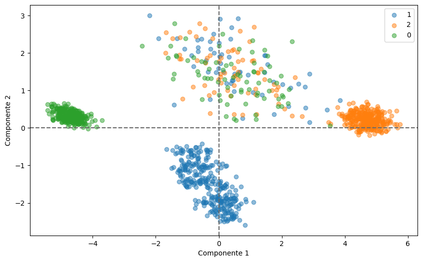

```python
pca_model = modelo_reduccion(metodo='pca', df_scaled=datos_escalados, pred=pred, n_components=2)
```

```
No Stress = 0, Eustress = 1 y Distress = 2
```

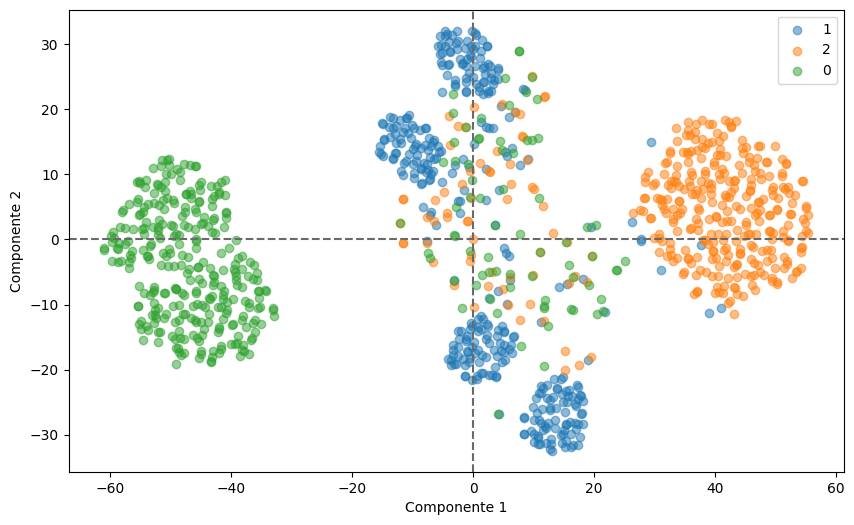

```python
tsne_model = modelo_reduccion(metodo='TSNE', df_scaled=datos_escalados, pred=pred, n_components=2)
```

```
No Stress = 0, Eustress = 1 y Distress = 2
```

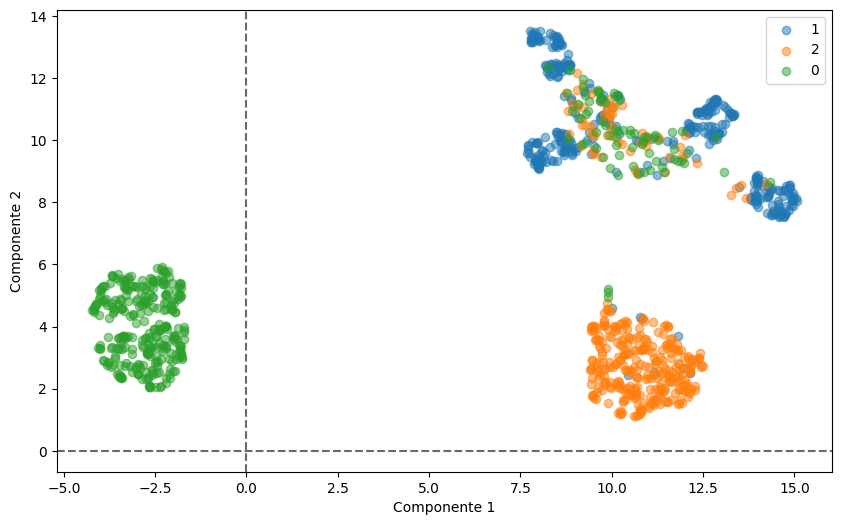

```python
umap_model = modelo_reduccion(metodo='UMAP', df_scaled=datos_escalados, pred=pred, n_components=2, n_neighbors=6) #n_neighbors=15 default
```

## Parte 3

- c) Ejecute el método de `KMeans(...)` con 3 clústeres (utilice los parámetros que considere más adecuados), tomando como entrada las dos primeras componentes generadas por `ACP`, `t-SNE` y `UMAP`. Grafique los respectivos planos principales utilizando colores según los grupos generados.

**Función para ejecutar los modelos `ACP`, `t-SNE` y `UMAP` e implementa kmeans.fit usando pred para identificar los clusters**  
También usa la funcion print_reduccion_dim, para imprimir Plano Principal

```python
def print_kmeans_con_reduccion_dim(metodo, df_scaled, n_components, kmedias_config, perplexity=10, n_neighbors=15):
  if metodo.upper() == 'PCA' or metodo.upper() == 'APC':
    modelo = PCA(n_components=n_components)
  elif metodo.upper() == 'TSNE' or metodo.upper() == 'T-SNE':
    modelo = TSNE(n_components=n_components, perplexity=perplexity, learning_rate='auto', init='random')
  elif metodo.upper() == 'UMAP':
    modelo = UMAP(n_components=n_components, n_neighbors=n_neighbors)
  else:
    print("Función para modelo = PCA, TSNE o UMAP.")

  individuos = modelo.fit_transform(df_scaled)
  individuos = pd.DataFrame(individuos, index = df_scaled.index)

# ======== kmedias_with_algoritmo: elkan o lloyd ========
  kmedias_with_algoritmo = kmedias_config.fit(individuos)
  datos_algoritmo = df_codificado.copy()
  datos_algoritmo["cluster"] = kmedias_with_algoritmo.labels_
  pred = datos_algoritmo["cluster"]

  print_reduccion_dim(individuos, pred)
  return datos_algoritmo["cluster"]
```

### **PCA**

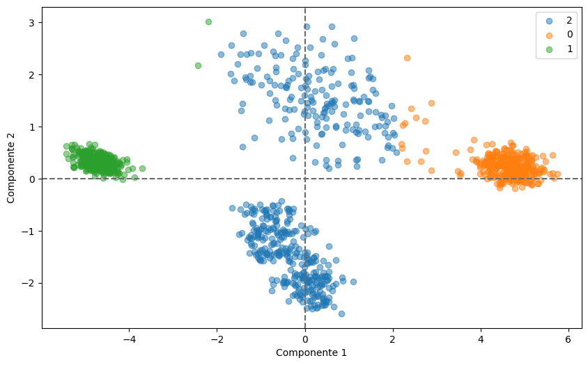

```python
kmedias_lloyd_pca = KMeans(n_clusters=3, n_init=15, max_iter=100, algorithm="lloyd") # elkan, lloyd
grupos_pca = print_kmeans_con_reduccion_dim(metodo='pca', df_scaled=datos_escalados, n_components=2, kmedias_config=kmedias_lloyd_pca)
```

### **TSNE**

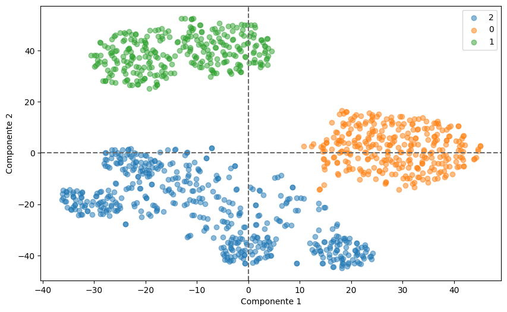

```python
kmedias_lloyd_tsne = KMeans(n_clusters=3, n_init=10, max_iter=150, algorithm="lloyd") # elkan, lloyd
grupos_tsne = print_kmeans_con_reduccion_dim(metodo='tsne', df_scaled=datos_escalados, n_components=2, kmedias_config=kmedias_lloyd_tsne, perplexity=25)
# La perplejidad está relacionada con el número de vecinos más cercanos que se utiliza en otros múltiples algoritmos de aprendizaje.
# Los conjuntos de datos más grandes suelen requerir una mayor perplejidad.
# Considere seleccionar un valor entre 5 y 50. Valores diferentes pueden generar resultados significativamente diferentes.
```

### **UMAP**

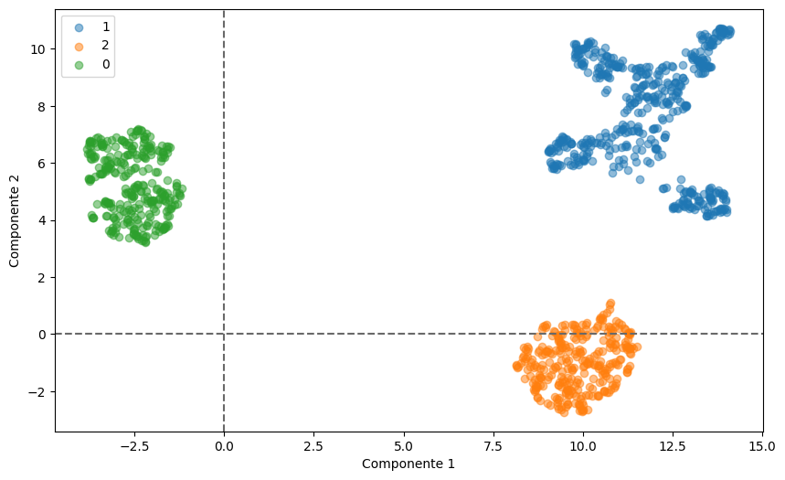

```python
kmedias_elkan_umap = KMeans(n_clusters=3, n_init=10, max_iter=100, algorithm="elkan") # elkan, lloyd
grupos_umap = print_kmeans_con_reduccion_dim(metodo='UMAP', df_scaled=datos_escalados, n_components=2, kmedias_config=kmedias_elkan_umap, n_neighbors=6) #n_neighbors=15 default
```

## Parte 4

- d) Compare e interprete los resultados obtenidos en el punto anterior mediante gráficos de barras y gráficos tipo radar. Cuál de los métodos genera mejores resultados?

```python
# Calculo de las inercias
def incercia_km(datos, grupos, promedios):
  promedios_total = datos.mean()
  inercia_total = 0
  for i in range(datos.shape[0]):
    inercia_total = inercia_total + np.sum((datos.iloc[i, :] - promedios_total) ** 2)

  intra_clase = 0
  for i in range(datos.shape[0]):
    intra_clase = intra_clase + np.sum((datos.iloc[i, :] - promedios.iloc[grupos[i], :]) ** 2)

  inter_clase = 0
  for i in range(promedios.shape[0]):
    n = np.sum(grupos == i)
    inter_clase = inter_clase + (n * np.sum((promedios_total - promedios.iloc[i, :]) ** 2))

  return (f"intra_clase: {round(intra_clase, 2)}, "
          f"inter_clase: {round(inter_clase,2)}, "
          f"inercia_total: {round(inercia_total,2)}")

# Grafico de barrras
def graficar_barras_promedios(promedios):
  """
  Grafica un barplot de promedios por clúster.

  Parámetros
  ----------
  promedios : pandas.DataFrame
      DataFrame resultante de agrupar por 'cluster' y promediar.
      - El índice debe ser el nombre/ID del clúster.
      - Las columnas son las variables (materias).
  """
  fig, ax = plt.subplots(figsize=(12, 7))  # tamaño
  no_print = promedios.plot(kind='bar', ax=ax)
  no_print = ax.set_xlabel('Clúster', fontsize=6)
  no_print = ax.set_ylabel('Promedio', fontsize=6)
  no_print = ax.legend(title="Materia", title_fontsize=13, fontsize=11, loc='upper right', bbox_to_anchor=(1.35, 1))
  plt.show()

# Grafico de radar
def graficar_radar_promedios(promedios):
  """
  Grafica un radar chart (polar) para los promedios por clúster.

  Parámetros
  ----------
  promedios : pandas.DataFrame
      DataFrame con índice = clústeres y columnas = variables.
  """
  # Escalado 0-100
  scaler = MinMaxScaler()
  escalar_promedios = pd.DataFrame(
      scaler.fit_transform(promedios),
      columns=promedios.columns,
      index=promedios.index
  )
  escalar_promedios = escalar_promedios * 100
  columnas = escalar_promedios.columns
  N = len(columnas)
  # Ángulos (cerrando el polígono)
  theta = np.linspace(0, 2 * np.pi, N, endpoint=False)
  theta = np.concatenate([theta, [theta[0]]])
  fig, ax = plt.subplots(figsize=(9, 9), subplot_kw={"projection": "polar"})
  no_print = ax.set_theta_zero_location("N")
  no_print = ax.set_theta_direction(-1)
  no_print = ax.set_rlabel_position(90)
  no_print = ax.spines["polar"].set_zorder(1)
  no_print = ax.spines["polar"].set_color("lightgrey")
  # Trazar cada clúster
  for fila in escalar_promedios.index:
      valores = escalar_promedios.loc[fila, columnas].values.tolist()
      valores = valores + [valores[0]]  # cerrar polígono
      no_print = ax.plot(theta, valores, linewidth=1.75, linestyle="solid",
                          label=f"Cluster {fila}", marker="o", markersize=10)
      no_print = ax.fill(theta, valores, alpha=0.50)
  # Ejes y leyendas
  no_print = plt.yticks([0, 25, 50, 75, 100], ["0", "25", "50", "75", "100"], color="black", size=12)
  no_print = plt.ylim(-10, 100)
  no_print = plt.xticks(theta, columnas.to_list() + [columnas[0]], color="black", size=12)
  no_print = plt.legend(loc="upper left", bbox_to_anchor=(1.3, 1.1))
  plt.show()
```

```python
# # grupos_pca
# datos_cluster_pca = df_codificado.copy()
# datos_cluster_pca["cluster"] = grupos_pca
# # datos_cluster_pca.head()
# promedios_pca = datos_cluster_pca.groupby("cluster").mean()
# # promedios_pca
# # incercia_km(df_codificado, grupos_pca, promedios_pca)
# graficar_barras_promedios(promedios_pca)
# graficar_radar_promedios(promedios_pca)

# Calculo general para graficar promedios de los clusters
def print_kmeans_con_reduccion_dim_bar_radar_chart(df_codificado, grupos_redu_dim):
  datos_cluster = df_codificado.copy()
  datos_cluster["cluster"] = grupos_redu_dim
  promedios = datos_cluster.groupby("cluster").mean()
  print(incercia_km(df_codificado, grupos_redu_dim, promedios))
  graficar_barras_promedios(promedios)
  graficar_radar_promedios(promedios)
```

**PCA**

```
intra_clase: 75299.7, inter_clase: 152411.52, inercia_total: 227711.23
```

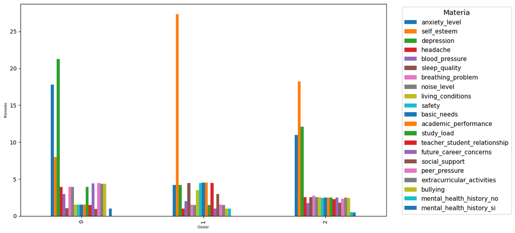

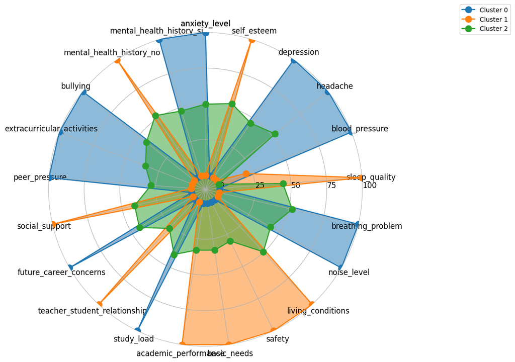

```python
print_kmeans_con_reduccion_dim_bar_radar_chart(df_codificado, grupos_pca)
```

**T-SNE**

```
intra_clase: 74947.97, inter_clase: 152763.26, inercia_total: 227711.23
```

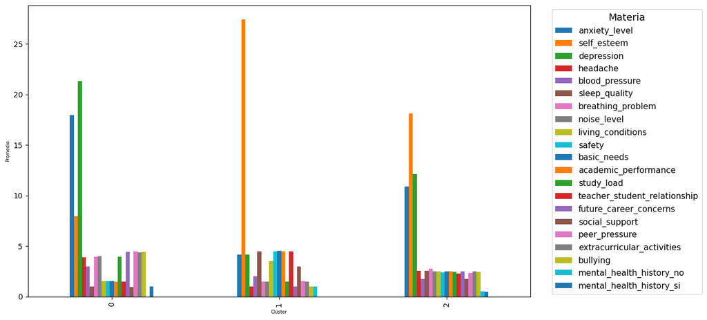

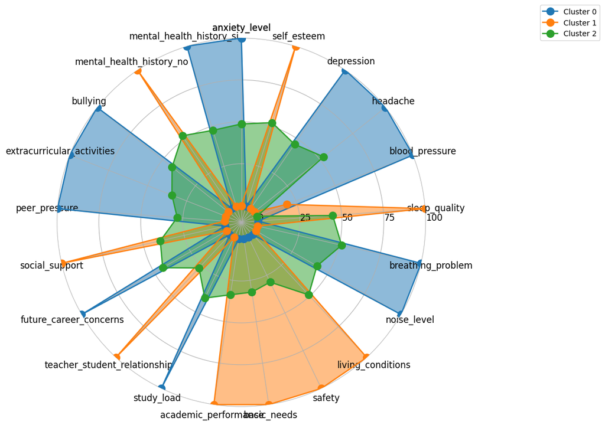

```python
print_kmeans_con_reduccion_dim_bar_radar_chart(df_codificado, grupos_tsne)
```

**UMAP**

```
intra_clase: 74631.69, inter_clase: 153079.53, inercia_total: 227711.23
```

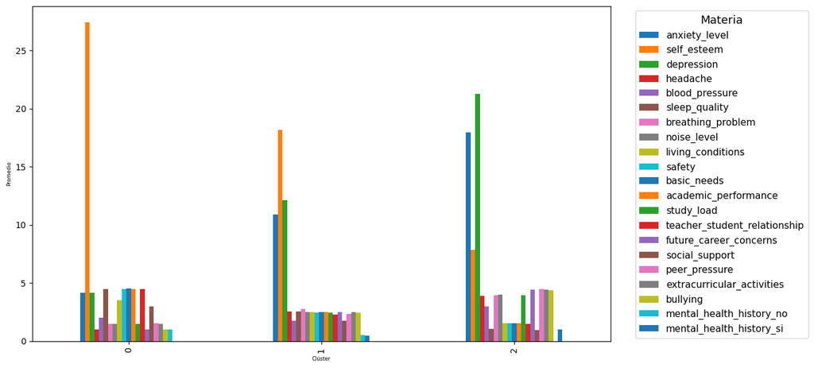

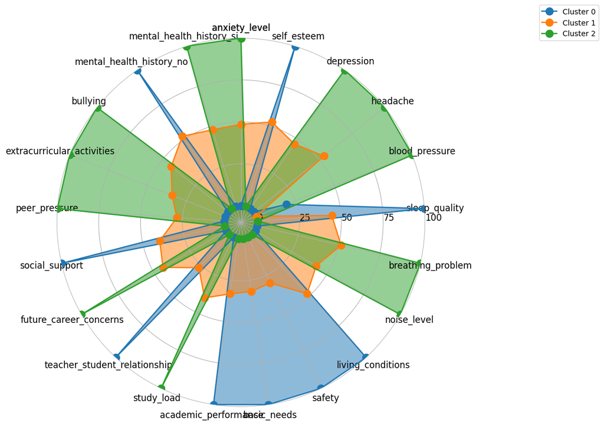

```python
print_kmeans_con_reduccion_dim_bar_radar_chart(df_codificado, grupos_umap)
```